# Self-Driving Car Engineer Nanodegree

## Project: Build a Traffic Sign Recognition Classifier

### Imports

```python
import pickle
import matplotlib.pyplot as plt
import cv2
import math
import numpy as np
import random
from sklearn.utils import shuffle
import tensorflow as tf
from tensorflow.contrib.layers import flatten
import os

%matplotlib inline
```

## Step 0: Load The Data

```python
# Load data from https://s3-us-west-1.amazonaws.com/udacity-selfdrivingcar/traffic-signs-data.zip

training_file = 'traffic-signs-data/train.p'
validation_file= 'traffic-signs-data/valid.p'
testing_file = 'traffic-signs-data/test.p'

# Load pickled data
with open(training_file, mode='rb') as f:
    train = pickle.load(f)
with open(validation_file, mode='rb') as f:
    valid = pickle.load(f)
with open(testing_file, mode='rb') as f:
    test = pickle.load(f)

X_train, y_train = np.array(train['features']), np.array(train['labels'])
X_valid, y_valid = np.array(valid['features']), np.array(valid['labels'])
X_test, y_test = np.array(test['features']), np.array(test['labels'])
```

## Step 1: Dataset Summary & Exploration

### Provide a Basic Summary of the Data Set Using Python, Numpy and/or Pandas

```python
def show_hist(img):
    color = ('b','g','r')
    for i,col in enumerate(color):
        histr = cv2.calcHist([img],[i],None,[256],[0,256])
        plt.plot(histr,color = col)
        plt.xlim([0,256])
```

```python
# Check that n_X and n_Y is the same for each set
assert X_train.shape[0] == y_train.shape[0]
assert X_valid.shape[0] == y_valid.shape[0]
assert X_test.shape[0] == y_test.shape[0]

# Number of training examples
n_train = X_train.shape[0]

# Number of validation examples
n_validation = X_valid.shape[0]

# Number of testing examples.
n_test = X_test.shape[0]

# What's the shape of an traffic sign image?
image_shape = (X_train.shape[1], X_train.shape[2])

# How many unique classes/labels there are in the dataset.
n_classes = len(np.unique(y_train))

print("Number of training examples =", n_train)
print("Number of training examples =", n_validation)
print("Number of testing examples =", n_test)
print("Image data shape =", image_shape)
print("Number of classes =", n_classes)
```

```
Number of training examples = 34799
Number of training examples = 4410
Number of testing examples = 12630
Image data shape = (32, 32)
Number of classes = 43
```

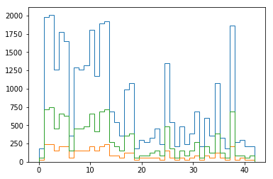

```python
# Histogram of the labels in the datasets
plt.hist(y_train, bins=n_classes, histtype='step')
plt.hist(y_valid, bins=n_classes, histtype='step')
plt.hist(y_test, bins=n_classes, histtype='step')
plt.savefig('examples/hist.png')
```

### Include an exploratory visualization of the dataset

Visualize the German Traffic Signs Dataset using the pickled file(s). This is open ended, suggestions include: plotting traffic sign images, plotting the count of each sign, etc.

The [Matplotlib](http://matplotlib.org/) [examples](http://matplotlib.org/examples/index.html) and [gallery](http://matplotlib.org/gallery.html) pages are a great resource for doing visualizations in Python.

**NOTE:** It's recommended you start with something simple first. If you wish to do more, come back to it after you've completed the rest of the sections. It can be interesting to look at the distribution of classes in the training, validation and test set. Is the distribution the same? Are there more examples of some classes than others?

```python
def show_images(imgs, titles,  width=32, height=32, columns=3, cmap=None):
    fig = plt.figure(figsize=(width, height))
    for i in range(len(imgs)):
        ax = fig.add_subplot(math.ceil(len(imgs)/columns), columns, i+1)
        ax.set_title(titles[i], fontsize=32)
        if cmap:
            plt.imshow(imgs[i], cmap=cmap)
        else:
            plt.imshow(imgs[i])
```

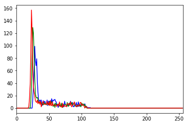

```python
# Data exploration
n_images = 6
n_rows = 1
index = random.sample(range(0, len(X_train)), n_images)

images = [X_train[index[i]] for i in range(n_images)]
labels = [y_train[index[i]] for i in range(n_images)]

#show_images(images, labels, width=32, height=32, columns=n_images//n_rows)
show_hist(X_train[0])
plt.savefig('examples/original_rgb_hist.png')
```

## Step 2: Design and Test a Model Architecture

Design and implement a deep learning model that learns to recognize traffic signs. Train and test your model on the [German Traffic Sign Dataset](http://benchmark.ini.rub.de/?section=gtsrb&subsection=dataset).

The LeNet-5 implementation shown in the classroom at the end of the CNN lesson is a solid starting point. You'll have to change the number of classes and possibly the preprocessing, but aside from that it's plug and play!

With the LeNet-5 solution from the lecture, you should expect a validation set accuracy of about 0.89. To meet specifications, the validation set accuracy will need to be at least 0.93. It is possible to get an even higher accuracy, but 0.93 is the minimum for a successful project submission.

There are various aspects to consider when thinking about this problem:

- Neural network architecture (is the network over or underfitting?)
- Play around preprocessing techniques (normalization, rgb to grayscale, etc)
- Number of examples per label (some have more than others).
- Generate fake data.

Here is an example of a [published baseline model on this problem](http://yann.lecun.com/exdb/publis/pdf/sermanet-ijcnn-11.pdf). It's not required to be familiar with the approach used in the paper but, it's good practice to try to read papers like these.

Minimally, the image data should be normalized so that the data has mean zero and equal variance. For image data, `(pixel - 128)/ 128` is a quick way to approximately normalize the data and can be used in this project.

Other pre-processing steps are optional. You can try different techniques to see if it improves performance.

Use the code cell (or multiple code cells, if necessary) to implement the first step of your project.

### Pre-process the Data Set (normalization, grayscale, etc.)

```python
def clahe(img, gridsize=1):
    # Convert image to LAB
    lab = cv2.cvtColor(img, cv2.COLOR_BGR2LAB)

    # Split image into planes
    lab_planes = cv2.split(lab)

    # Apply CLAHE on L plane of image
    clahe = cv2.createCLAHE(clipLimit=2.0,tileGridSize=(gridsize,gridsize))
    lab_planes[0] = clahe.apply(lab_planes[0])

    # Merge planes back together
    lab = cv2.merge(lab_planes)

    # convert LAB back to BGR
    bgr = cv2.cvtColor(lab, cv2.COLOR_LAB2BGR)
    return bgr
```

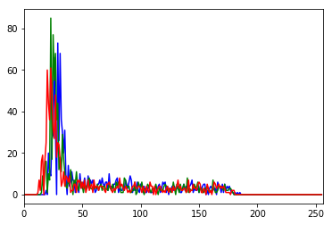

```python
# Apply CLAHE
X_train = np.array([clahe(img) for img in X_train])
X_valid = np.array([clahe(img) for img in X_valid])
X_test  = np.array([clahe(img) for img in X_test])

show_hist(X_train[0])
plt.savefig('examples/clahe_rgb_hist.png')
```

```python
def normalize(dataset):
    return (dataset - 128.) / 128.
```

```python
# Apply normalization
X_train = normalize(X_train)
X_valid = normalize(X_valid)
X_test = normalize(X_test)
```

```python
# Shuffel data
X_train, y_train = shuffle(X_train, y_train)
```

### Model Architecture

```python
EPOCHS = 20
BATCH_SIZE = 128

mu = 0
sigma = 0.1

learning_rate = 0.001
```

```python
# Convolution Layer
def conv_layer(input, size_in, size_out, name='conv', dropout=False):
    w = tf.Variable(tf.truncated_normal(shape=(5, 5, size_in, size_out), mean = mu, stddev = sigma))
    b = tf.Variable(tf.zeros(size_out))
    conv   = tf.nn.conv2d(input, w, strides=[1, 1, 1, 1], padding='VALID', name=name) + b

     # Activation.
    conv = tf.nn.relu(conv, name='{}_relu'.format(name))

    # Pooling
    conv = tf.nn.max_pool(conv, ksize=[1, 2, 2, 1], strides=[1, 2, 2, 1], padding='SAME', name='{}_maxpool'.format(name))

    if dropout:
        conv = tf.nn.dropout(conv, keep_prob_conv, name='{}_dropout'.format(name))

    return conv
```

```python
# Fully connected Layer
def fc_layer(input, size_in, size_out, activation='relu', name='fc', dropout=False):
    w = tf.Variable(tf.truncated_normal(shape=(size_in, size_out), mean = mu, stddev = sigma))
    b = tf.Variable(tf.zeros(size_out))
    fc = tf.add(tf.matmul(input, w, name=name), b)

    # Activation.
    if not activation or activation=='no':
        fc = fc
    elif activation == 'relu':
        fc = tf.nn.relu(fc, name='{}_relu'.format(name))

    if dropout:
        fc = tf.nn.dropout(fc, keep_prob_fc, name='{}_dropout'.format(name))

    return fc
```

```python
# Tensorflow model definition
def model(x):
    # Layer 1: Convolutional. Input = 32x32x3. Output = 28x28x6.
    conv1 = conv_layer(x, 3, 6, 'conv1', dropout=True)

    # Layer 2: Convolutional. Output = 10x10x16.
    conv2 = conv_layer(conv1, 6, 16, 'conv2', dropout=True)
    # Flatten. Input = 5x5x16. Output = 400.
    fc_in = flatten(conv2)

    # Layer 3: Fully Connected. Input = 400. Output = 120.
    fc1 = fc_layer(fc_in, 400, 120, 'relu', 'fc1', dropout=True)

    # Layer 4: Fully Connected. Input = 120. Output = 84.
    fc2 = fc_layer(fc1, 120, 84, 'relu', 'fc2', dropout=True)

    # Layer 5: Fully Connected. Input = 84. Output = n_classes.
    logits = fc_layer(fc2, 84, n_classes, activation=None, name='fc3', dropout=False)

    return logits
```

#### Model

| Layer | Name | Description |
| --- | --- | --- |
| Input |  | 32x32x3 RGB image |
| Convolution 5x5 | conv1 | 1x1 strides, VALID padding, outputs 28x28x6 |
| RELU | conv1_relu |  |
| Max pooling | conv1_maxpool | 2x2 strides, 2x2 kernel, SAME padding, outputs 14x14x6 |
| Dropout | conv1_dropout | 0.8 keep_rate |
| Convolution 5x5 | conv2 | 1x1 strides, VALID padding, outputs 10x10x16 |
| RELU | conv2_relu |  |
| Max pooling | conv2_maxpool | 2x2 strides, 2x2 kernelSAME padding, outputs 5x5x16 |
| Dropout | conv2_dropout | 0.8 keep_rate |
| Fully connected | fc1 | 400 inputs, outputs 120 |
| RELU | fc1_relu |  |
| Dropout | fc1_dropout | 0.5 keep_rate |
| Fully connected | fc2 | 120 inputs, 84 outputs |
| RELU | fc2_relu |  |
| Dropout | fc2_dropout | 0.5 keep_rate |
| Fully connected | fc3 | 84 inputs, outputs 43 (#classes) |

```python
x = tf.placeholder(tf.float32, (None, 32, 32, 3), name='x')
y = tf.placeholder(tf.int32, (None), name='y')
one_hot_y = tf.one_hot(y, n_classes)

keep_prob_fc   = tf.placeholder(tf.float32)
keep_prob_conv = tf.placeholder(tf.float32)
```

### Train, Validate and Test the Model

```python
logits = model(x)
cross_entropy = tf.nn.softmax_cross_entropy_with_logits(labels=one_hot_y, logits=logits)
loss_operation = tf.reduce_mean(cross_entropy)
optimizer = tf.train.AdamOptimizer(learning_rate=learning_rate)
training_operation = optimizer.minimize(loss_operation)
```

[output not shown]

```python
# Model Evaluation
correct_prediction = tf.equal(tf.argmax(logits, 1), tf.argmax(one_hot_y, 1))
accuracy_operation = tf.reduce_mean(tf.cast(correct_prediction, tf.float32))
saver = tf.train.Saver()

def evaluate(X_data, y_data):
    num_examples = len(X_data)
    total_accuracy = 0
    sess = tf.get_default_session()
    for offset in range(0, num_examples, BATCH_SIZE):
        batch_x, batch_y = X_data[offset:offset+BATCH_SIZE], y_data[offset:offset+BATCH_SIZE]
        accuracy = sess.run(accuracy_operation, feed_dict={x: batch_x, y: batch_y, keep_prob_fc: 1, keep_prob_conv: 1})
        total_accuracy += (accuracy * len(batch_x))
    return total_accuracy / num_examples
```

```python
# Train Model
with tf.Session() as sess:
    sess.run(tf.global_variables_initializer())

    print("Training...")
    print()
    for i in range(EPOCHS):
        X_train, y_train = shuffle(X_train, y_train)
        for offset in range(0, n_train, BATCH_SIZE):
            end = offset + BATCH_SIZE
            batch_x, batch_y = X_train[offset:end], y_train[offset:end]
            sess.run(training_operation, feed_dict={x: batch_x, y: batch_y, keep_prob_fc: 0.5, keep_prob_conv: 0.8})

        cost = sess.run(loss_operation, feed_dict={x: batch_x, y: batch_y, keep_prob_fc: 1, keep_prob_conv: 1})
        validation_accuracy = evaluate(X_valid, y_valid)
        train_accuracy = evaluate(X_train, y_train)
        print("Epoch {:<3} - Cost = {:.5f} - Train Accuracy = {:.3f} - Validation Accuracy = {:.3f}".format((i+1), cost, train_accuracy, validation_accuracy))

    saver.save(sess, './traffic-sign-classifier.ckpt')
    print("Model saved")
```

```
Training...

Epoch 1   - Cost = 1.48297 - Train Accuracy = 0.554 - Validation Accuracy = 0.523
Epoch 2   - Cost = 0.81415 - Train Accuracy = 0.762 - Validation Accuracy = 0.727
Epoch 3   - Cost = 0.54071 - Train Accuracy = 0.837 - Validation Accuracy = 0.808
Epoch 4   - Cost = 0.39202 - Train Accuracy = 0.898 - Validation Accuracy = 0.874
Epoch 5   - Cost = 0.34205 - Train Accuracy = 0.921 - Validation Accuracy = 0.890
Epoch 6   - Cost = 0.28186 - Train Accuracy = 0.929 - Validation Accuracy = 0.904
Epoch 7   - Cost = 0.21105 - Train Accuracy = 0.948 - Validation Accuracy = 0.926
Epoch 8   - Cost = 0.28308 - Train Accuracy = 0.955 - Validation Accuracy = 0.928
Epoch 9   - Cost = 0.09272 - Train Accuracy = 0.957 - Validation Accuracy = 0.927
Epoch 10  - Cost = 0.13869 - Train Accuracy = 0.968 - Validation Accuracy = 0.939
Epoch 11  - Cost = 0.10834 - Train Accuracy = 0.967 - Validation Accuracy = 0.939
Epoch 12  - Cost = 0.17861 - Train Accuracy = 0.971 - Validation Accuracy = 0.945
Epoch 13  - Cost = 0.08296 - Train Accuracy = 0.973 - Validation Accuracy = 0.949
Epoch 14  - Cost = 0.16383 - Train Accuracy = 0.973 - Validation Accuracy = 0.937
Epoch 15  - Cost = 0.08951 - Train Accuracy = 0.976 - Validation Accuracy = 0.952
Epoch 16  - Cost = 0.11389 - Train Accuracy = 0.981 - Validation Accuracy = 0.956
Epoch 17  - Cost = 0.04986 - Train Accuracy = 0.981 - Validation Accuracy = 0.956
Epoch 18  - Cost = 0.07372 - Train Accuracy = 0.982 - Validation Accuracy = 0.958
Epoch 19  - Cost = 0.03654 - Train Accuracy = 0.984 - Validation Accuracy = 0.958
Epoch 20  - Cost = 0.04058 - Train Accuracy = 0.983 - Validation Accuracy = 0.960
Model saved
```

```python
# Test model using test set
with tf.Session() as sess:
    # Restore TF model
    saver = tf.train.import_meta_graph('traffic-sign-classifier.ckpt.meta')
    saver.restore(sess, "traffic-sign-classifier.ckpt")

    test_accuracy = evaluate(X_test, y_test)
    print('Test Accuracy: {:.3f}'.format(test_accuracy))
```

```
INFO:tensorflow:Restoring parameters from traffic-sign-classifier.ckpt
Test Accuracy: 0.947
```

## Step 3: Test a Model on New Images

Five pictures of German traffic signs from the web were used to test the model.

### Load and Output the Images

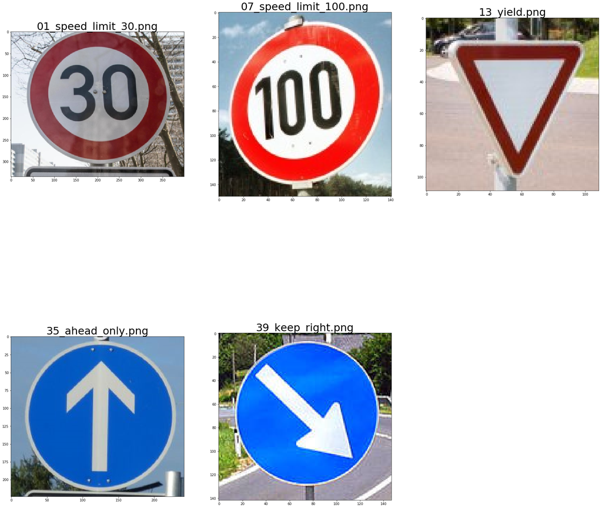

```python
# Load the images and plot them here.
image_path = os.path.join('.', 'traffic-signs-data', 'internet_images')
image_names = ['01_speed_limit_30.png', '07_speed_limit_100.png', '13_yield.png', '35_ahead_only.png', '39_keep_right.png']

X_web = []

for name in image_names:
    im = cv2.cvtColor(cv2.imread(os.path.join(image_path, name)), cv2.COLOR_BGR2RGB)
    X_web.append(im)

X_web = np.array(X_web)
show_images(X_web, image_names)
```

### Process images

```python
# Rezise images
X_web = np.array([cv2.resize(img, (32,32)) for img in X_web])
```

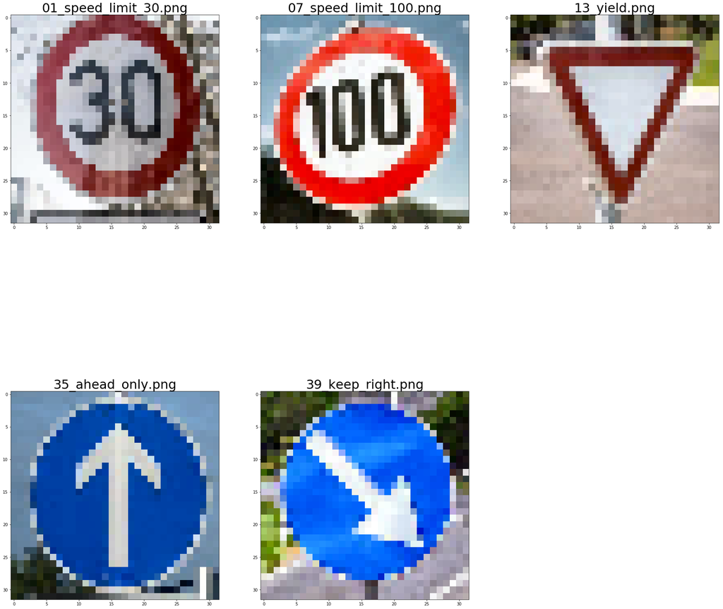

```python
# Apply CLAHE and Normalize
X_web = np.array([clahe(img) for img in X_web])
show_images(X_web, image_names)
X_web = normalize(X_web)
```

### Predict the Sign Type for Each Image

```python
# Predict the five images above using the trained model
with tf.Session() as sess:
    # Restore TF model
    saver = tf.train.import_meta_graph('traffic-sign-classifier.ckpt.meta')
    saver.restore(sess, "traffic-sign-classifier.ckpt")

    classification = sess.run(tf.argmax(logits, 1), feed_dict={x: X_web,
                                                               keep_prob_conv: 1,
                                                               keep_prob_fc: 1})
    print(classification)
```

```
INFO:tensorflow:Restoring parameters from traffic-sign-classifier.ckpt
[ 1  1 13 35 38]
```

### Analyze Performance

```python
# Calculate the accuracy for these 5 new images
y_web = [1, 7, 13, 35, 38]

with tf.Session() as sess:
    saver = tf.train.import_meta_graph('traffic-sign-classifier.ckpt.meta')
    saver.restore(sess, "traffic-sign-classifier.ckpt")
    web_accuracy = evaluate(X_web, y_web)
    print('Accuracy: {:.3f}'.format(web_accuracy))
```

```
INFO:tensorflow:Restoring parameters from traffic-sign-classifier.ckpt
Accuracy: 0.800
```

### Output Top 5 Softmax Probabilities For Each Image Found on the Web

```python
# Print out the top five softmax probabilities for the predictions on the German traffic sign images found on the web.
import tensorflow as tf

# Restore TF model
with tf.Session() as sess:
    saver = tf.train.import_meta_graph('traffic-sign-classifier.ckpt.meta')
    saver.restore(sess, "traffic-sign-classifier.ckpt")

    softmax = sess.run(tf.nn.softmax(logits), feed_dict={x: X_web,
                                                         keep_prob_conv: 1,
                                                         keep_prob_fc: 1})
    probs, pred = tf.nn.top_k(softmax, k=5)
    probs = probs.eval()
    y_hat = pred.eval()

    print(probs)
    print(y_hat)
```

```
INFO:tensorflow:Restoring parameters from traffic-sign-classifier.ckpt
[[4.9134520e-01 3.3492240e-01 9.1550335e-02 5.0645176e-02 8.7187709e-03]
 [4.6534279e-01 1.4758404e-01 1.1336590e-01 1.1327925e-01 7.3034607e-02]
 [1.0000000e+00 1.0840442e-25 2.9474091e-27 2.4244990e-28 2.3066314e-31]
 [9.9998593e-01 1.4027931e-05 1.5859723e-12 1.1395660e-14 5.0211696e-17]
 [1.0000000e+00 2.4397822e-11 7.6881914e-20 4.9364734e-26 3.7949058e-31]]
[[ 1  0 16  2  4]
 [ 1  7 40  5  2]
 [13 12  9 15 17]
 [35 34 33 36 37]
 [38 34 36 40 20]]
```

## Step 4 (Optional): Visualize the Neural Network's State with Test Images

```python
# Visualize network's feature maps

# image_input: the test image being fed into the network to produce the feature maps
# tf_activation: should be a tf variable name used during your training procedure that represents the calculated state of a specific weight layer
# activation_min/max: can be used to view the activation contrast in more detail, by default matplot sets min and max to the actual min and max values of the output
# plt_num: used to plot out multiple different weight feature map sets on the same block, just extend the plt number for each new feature map entry

def outputFeatureMap(image_input, tf_activation, activation_min=-1, activation_max=-1 ,plt_num=1):
    # Here make sure to preprocess your image_input in a way your network expects
    # with size, normalization, ect if needed
    # image_input =
    # Note: x should be the same name as your network's tensorflow data placeholder variable
    # If you get an error tf_activation is not defined it may be having trouble accessing the variable from inside a function
    activation = tf_activation.eval(session=sess,feed_dict={x : image_input})
    featuremaps = activation.shape[3]
    plt.figure(plt_num, figsize=(15,15))
    for featuremap in range(featuremaps):
        plt.subplot(6,8, featuremap+1) # sets the number of feature maps to show on each row and column
        plt.title('FeatureMap ' + str(featuremap)) # displays the feature map number
        if activation_min != -1 & activation_max != -1:
            plt.imshow(activation[0,:,:, featuremap], interpolation="nearest", vmin =activation_min, vmax=activation_max, cmap="gray")
        elif activation_max != -1:
            plt.imshow(activation[0,:,:, featuremap], interpolation="nearest", vmax=activation_max, cmap="gray")
        elif activation_min !=-1:
            plt.imshow(activation[0,:,:, featuremap], interpolation="nearest", vmin=activation_min, cmap="gray")
        else:
            plt.imshow(activation[0,:,:, featuremap], interpolation="nearest", cmap="gray")
```

```
INFO:tensorflow:Restoring parameters from traffic-sign-classifier.ckpt
```

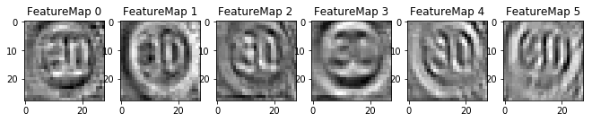

```python
# Visualize convolution layer 1
with tf.Session() as sess:
    saver = tf.train.import_meta_graph('traffic-sign-classifier.ckpt.meta')
    saver.restore(sess, "traffic-sign-classifier.ckpt")
    conv1 = sess.graph.get_tensor_by_name('conv1:0')
    outputFeatureMap(X_web, conv1)
```

```
INFO:tensorflow:Restoring parameters from traffic-sign-classifier.ckpt
```

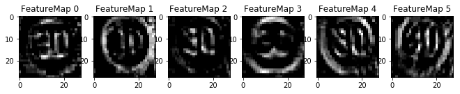

```python
# Visualize activation (ReLU) convolution layer 1
with tf.Session() as sess:
    saver = tf.train.import_meta_graph('traffic-sign-classifier.ckpt.meta')
    saver.restore(sess, "traffic-sign-classifier.ckpt")
    conv1_relu = sess.graph.get_tensor_by_name('conv1_relu:0')
    outputFeatureMap(X_web, conv1_relu)
```

```
INFO:tensorflow:Restoring parameters from traffic-sign-classifier.ckpt
```

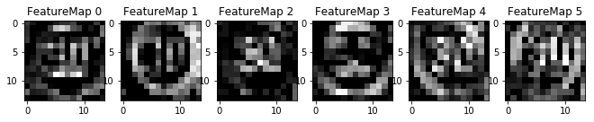

```python
# Visualize max pooling convolution layer 1
with tf.Session() as sess:
    saver = tf.train.import_meta_graph('traffic-sign-classifier.ckpt.meta')
    saver.restore(sess, "traffic-sign-classifier.ckpt")
    conv1_maxpool = sess.graph.get_tensor_by_name('conv1_maxpool:0')
    outputFeatureMap(X_web, conv1_maxpool)
```